```python
import os
import random
import seaborn as sns
import numpy as np
import pandas as pd
import datetime
import multiprocessing as mp
from PIL import Image, ImageOps
import matplotlib.pyplot as plt
import matplotlib.image as mpimg
import tensorflow as tf
from tensorflow.keras.preprocessing.image import ImageDataGenerator, img_to_array, load_img, save_img
from tensorflow.keras.models import Sequential
from tensorflow.keras.layers import Conv2D, MaxPooling2D, Flatten, Dense, Dropout, BatchNormalization, Input
from tensorflow.keras.callbacks import EarlyStopping, ReduceLROnPlateau, TensorBoard
from keras.optimizers import Adam
from tensorflow.keras.regularizers import l1_l2
from sklearn.metrics import classification_report, confusion_matrix, f1_score
from pathlib import Path
import itertools
```

```python
import warnings
warnings.filterwarnings("ignore", category=UserWarning, module="tensorflow")
import logging
logging.getLogger('tensorflow').setLevel(logging.ERROR)
```

# 2.

## Generate Data

```python
x_sine = np.linspace(-np.pi, np.pi, 1000)
y_sine = np.sin(x_sine)
```

```python
x_arbitrary = np.linspace(-1, 1, 1000)
y_arbitrary = x_arbitrary**3 + x_arbitrary**2
```

## Define and Train Models

### Sin Function

```python
model_sine = Sequential([
    Dense(64, activation='relu', input_shape=(1,)),
    Dense(64, activation='relu'),
    Dense(1)
])

model_sine.compile(optimizer=Adam(learning_rate=0.01), loss='mse')
model_sine.fit(x_sine, y_sine, epochs=100, batch_size=32, verbose=0)
```

```
<keras.src.callbacks.history.History at 0x7f1f835dba90>
```

### Arbitrary Function

```python
model_arbitrary = Sequential([
    Dense(64, activation='relu', input_shape=(1,)),
    Dense(64, activation='relu'),
    Dense(1)
])

model_arbitrary.compile(optimizer=Adam(learning_rate=0.01), loss='mse')
model_arbitrary.fit(x_arbitrary, y_arbitrary, epochs=100, batch_size=32, verbose=0)
```

```
<keras.src.callbacks.history.History at 0x7f1f837e34f0>
```

## Plot Learned Mappings

### Sine Function in Range (π, 2π)

```
32/32 ━━━━━━━━━━━━━━━━━━━━ 0s 4ms/step
```

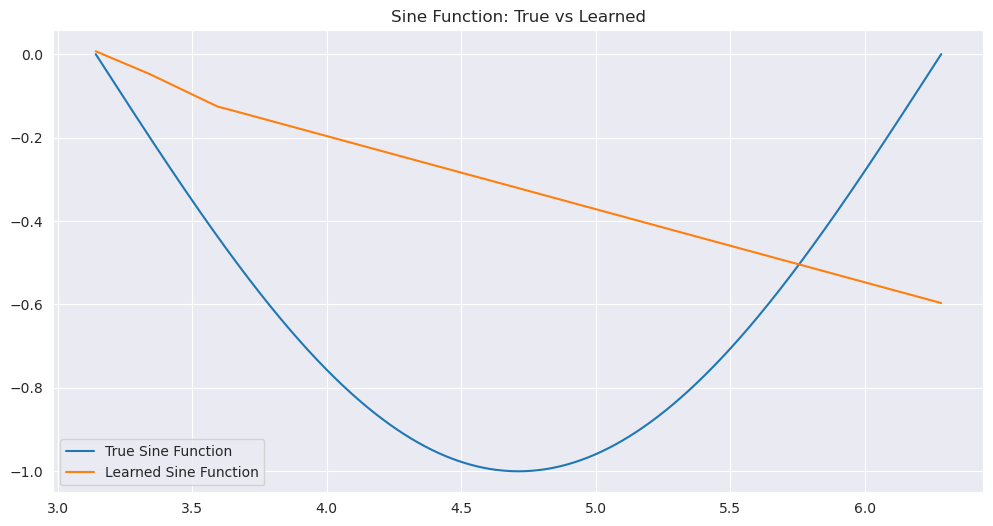

```python
x_sine_test = np.linspace(np.pi, 2*np.pi, 1000)
y_sine_true = np.sin(x_sine_test)
y_sine_pred = model_sine.predict(x_sine_test)

plt.figure(figsize=(12, 6))
plt.plot(x_sine_test, y_sine_true, label='True Sine Function')
plt.plot(x_sine_test, y_sine_pred, label='Learned Sine Function')
plt.legend()
plt.title('Sine Function: True vs Learned')
plt.show()
```

The model learned to approximate the sine function well within the training range but struggled outside of it. This highlights the importance of having a diverse training set that covers the expected range of inputs.

### Arbitrary Function in a Suitable Range

```
32/32 ━━━━━━━━━━━━━━━━━━━━ 0s 3ms/step
```

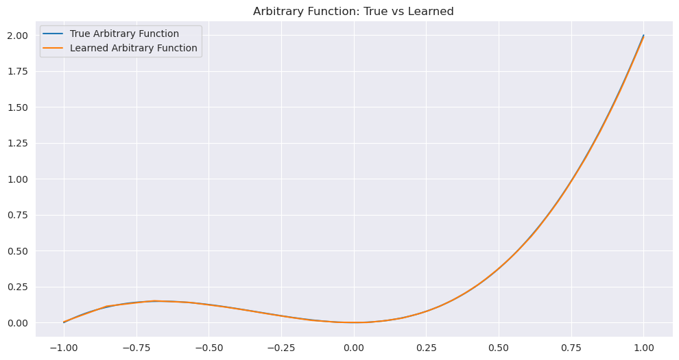

```python
x_arbitrary_test = np.linspace(-1, 1, 1000)
y_arbitrary_true = x_arbitrary_test**3 + x_arbitrary_test**2
y_arbitrary_pred = model_arbitrary.predict(x_arbitrary_test)

plt.figure(figsize=(12, 6))
plt.plot(x_arbitrary_test, y_arbitrary_true, label='True Arbitrary Function')
plt.plot(x_arbitrary_test, y_arbitrary_pred, label='Learned Arbitrary Function')
plt.legend()
plt.title('Arbitrary Function: True vs Learned')
plt.show()
```

The model approximated the chosen arbitrary function effectively within the training range, demonstrating the network's ability to learn complex mappings given sufficient training data and appropriate architecture.

## Model Summary

```python
model_sine.summary()
```

```
Model: "sequential_7"
```

```
┏━━━━━━━━━━━━━━━━━━━━━━━━━━━━━━━━━┳━━━━━━━━━━━━━━━━━━━━━━━━┳━━━━━━━━━━━━━━━┓
┃ Layer (type)                    ┃ Output Shape           ┃       Param # ┃
┡━━━━━━━━━━━━━━━━━━━━━━━━━━━━━━━━━╇━━━━━━━━━━━━━━━━━━━━━━━━╇━━━━━━━━━━━━━━━┩
│ dense_20 (Dense)                │ (None, 64)             │           128 │
├─────────────────────────────────┼────────────────────────┼───────────────┤
│ dense_21 (Dense)                │ (None, 64)             │         4,160 │
├─────────────────────────────────┼────────────────────────┼───────────────┤
│ dense_22 (Dense)                │ (None, 1)              │            65 │
└─────────────────────────────────┴────────────────────────┴───────────────┘
```

```
 Total params: 13,061 (51.02 KB)
```

```
 Trainable params: 4,353 (17.00 KB)
```

```
 Non-trainable params: 0 (0.00 B)
```

```
 Optimizer params: 8,708 (34.02 KB)
```

```python
model_arbitrary.summary()
```

```
Model: "sequential_6"
```

```
┏━━━━━━━━━━━━━━━━━━━━━━━━━━━━━━━━━┳━━━━━━━━━━━━━━━━━━━━━━━━┳━━━━━━━━━━━━━━━┓
┃ Layer (type)                    ┃ Output Shape           ┃       Param # ┃
┡━━━━━━━━━━━━━━━━━━━━━━━━━━━━━━━━━╇━━━━━━━━━━━━━━━━━━━━━━━━╇━━━━━━━━━━━━━━━┩
│ dense_17 (Dense)                │ (None, 64)             │           128 │
├─────────────────────────────────┼────────────────────────┼───────────────┤
│ dense_18 (Dense)                │ (None, 64)             │         4,160 │
├─────────────────────────────────┼────────────────────────┼───────────────┤
│ dense_19 (Dense)                │ (None, 1)              │            65 │
└─────────────────────────────────┴────────────────────────┴───────────────┘
```

```
 Total params: 13,061 (51.02 KB)
```

```
 Trainable params: 4,353 (17.00 KB)
```

```
 Non-trainable params: 0 (0.00 B)
```

```
 Optimizer params: 8,708 (34.02 KB)
```

The quality of the approximation depends on the range of the training data. The network may not generalize well outside the training range without appropriate data coverage. For example, sin function learning model which doesn't have sufficient data

# 3.

## Rename the pose directory to English

```python
# Path to the data
train_path = "107 yoga poses/train"
val_path = "107 yoga poses/val"
test_path = "107 yoga poses/test"
```

```python
# Path to the text file containing the folder names and their corresponding English names
txt_file_path = "107 yoga poses/yoga-poses-english.txt"
```

```python
# Read the text file and create a dictionary mapping original names to English names
name_mapping = {}
with open(txt_file_path, 'r') as file:
    for line in file:
        parts = line.strip().split(' - ')
        if len(parts) == 2:
            original_name, english_name = parts
            name_mapping[original_name.lower()] = english_name

# Function to rename directories in a given path
def rename_directories(path):
    for subdir in os.listdir(path):
        if subdir in name_mapping:
            original_subdir_path = os.path.join(path, subdir)
            new_subdir_path = os.path.join(path, name_mapping[subdir])
            os.rename(original_subdir_path, new_subdir_path)

# Rename directories in the train, test, and val folders
rename_directories(train_path)
rename_directories(test_path)
rename_directories(val_path)
```

## a)

### EDA

#### Check train - validation - test ratio

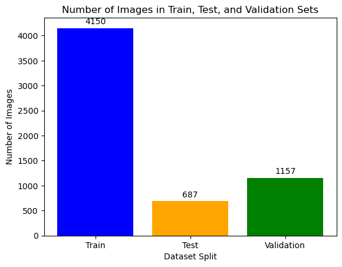

```python
# Initialize counters for each folder
train_count = 0
test_count = 0
val_count = 0

# Count the number of images in the train folder
for subdir, _, files in os.walk(train_path):
    train_count += len(files)

# Count the number of images in the test folder
for subdir, _, files in os.walk(test_path):
    test_count += len(files)

# Count the number of images in the val folder
for subdir, _, files in os.walk(val_path):
    val_count += len(files)

# Calculate the total number of images
total_count = train_count + test_count + val_count

# Calculate the split ratios
train_ratio = train_count / total_count
test_ratio = test_count / total_count
val_ratio = val_count / total_count

# Plot the counts as a bar graph
counts = [train_count, test_count, val_count]
labels = ['Train', 'Test', 'Validation']

plt.bar(labels, counts, color=['blue', 'orange', 'green'])

# Add the counts above the bars
for i, count in enumerate(counts):
    plt.text(i, count + max(counts) * 0.01, str(count), ha='center', va='bottom')

plt.xlabel('Dataset Split')
plt.ylabel('Number of Images')
plt.title('Number of Images in Train, Test, and Validation Sets')
plt.show()
```

```python
# Print the counts and the split ratios
print(f"Train count: {train_count}")
print(f"Test count: {test_count}")
print(f"Validation count: {val_count}")
print(f"Train-Test-Val split ratio: {train_ratio:.2f} - {test_ratio:.2f} - {val_ratio:.2f}")
```

```
Train count: 4150
Test count: 687
Validation count: 1157
Train-Test-Val split ratio: 0.69 - 0.11 - 0.19
```

#### Class Distribution

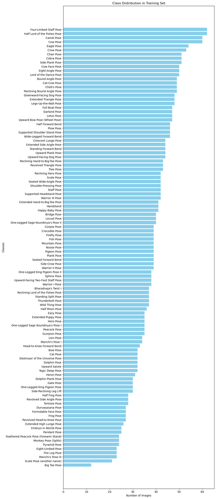

```python
def count_images_in_subfolders(folder_path):
    class_counts = {}
    for subdir in os.listdir(folder_path):
        subdir_path = os.path.join(folder_path, subdir)
        if os.path.isdir(subdir_path):
            class_counts[subdir] = len(os.listdir(subdir_path))
    return class_counts

train_counts = count_images_in_subfolders(train_path)

# Plot class distribution using horizontal bar chart
def plot_class_distribution(counts, title):
    sorted_counts = dict(sorted(counts.items(), key=lambda item: item[1], reverse=True))
    classes = list(sorted_counts.keys())
    values = list(sorted_counts.values())

    plt.figure(figsize=(10, len(classes) * 0.3))
    plt.barh(classes, values, color='skyblue')
    plt.xlabel('Number of Images')
    plt.ylabel('Classes')
    plt.title(title)
    plt.gca().invert_yaxis()
    plt.show()

plot_class_distribution(train_counts, 'Class Distribution in Training Set')
```

#### Sample Images

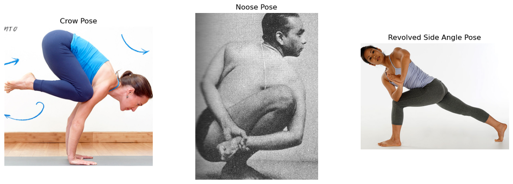

```python
def display_random_sample_images(folder_path, n=3):
    classes = os.listdir(folder_path)
    sampled_classes = random.sample(classes, n)

    plt.figure(figsize=(15, 5))
    for i, class_name in enumerate(sampled_classes):
        class_path = os.path.join(folder_path, class_name)
        img_name = random.choice(os.listdir(class_path))
        img_path = os.path.join(class_path, img_name)
        img = mpimg.imread(img_path)
        plt.subplot(1, n, i + 1)
        plt.imshow(img)
        plt.axis('off')
        plt.title(class_name)
    plt.show()

# Display 3 random sample images from 3 different train folders
display_random_sample_images(train_path, n=3)
```

#### Image ratio frequency

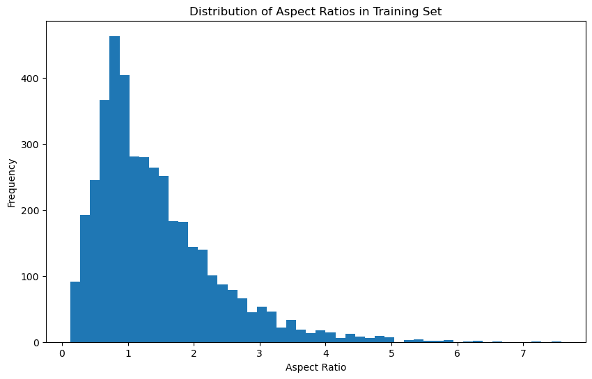

```python
def analyze_image_properties(folder_path):
    image_dimensions = []
    aspect_ratios = []
    for subdir in os.listdir(folder_path):
        subdir_path = os.path.join(folder_path, subdir)
        if os.path.isdir(subdir_path):
            for img_name in os.listdir(subdir_path):
                img_path = os.path.join(subdir_path, img_name)
                with Image.open(img_path) as img:
                    width, height = img.size
                    image_dimensions.append((width, height))
                    aspect_ratios.append(width / height)
    return image_dimensions, aspect_ratios

train_dimensions, train_aspect_ratios = analyze_image_properties(train_path)

# Plot aspect ratios
plt.figure(figsize=(10, 6))
plt.hist(train_aspect_ratios, bins=50)
plt.xlabel('Aspect Ratio')
plt.ylabel('Frequency')
plt.title('Distribution of Aspect Ratios in Training Set')
plt.show()
```

### Pre-processing

#### Data Augmentation

```python
# Define data augmentation
data_gen = ImageDataGenerator(
    rescale=1.0/255,
    rotation_range=10,
    width_shift_range=0.1,
    height_shift_range=0.1,
    shear_range=0.1,
    zoom_range=0.1,
    horizontal_flip=True,
    fill_mode='nearest'
)
```

```python
# Function to count images in subfolders
def count_images_in_subfolders(folder_path):
    class_counts = {}
    for subdir in os.listdir(folder_path):
        subdir_path = os.path.join(folder_path, subdir)
        if os.path.isdir(subdir_path):
            class_counts[subdir] = len(os.listdir(subdir_path))
    return class_counts
```

```python
# Get class counts
train_counts = count_images_in_subfolders(train_path)
max_count = max(train_counts.values())

# Function to augment images
def augment_images(folder_path, target_count, data_gen):
    for subdir in os.listdir(folder_path):
        subdir_path = os.path.join(folder_path, subdir)
        if os.path.isdir(subdir_path):
            current_count = len(os.listdir(subdir_path))
            if current_count < target_count:
                images = os.listdir(subdir_path)
                for i in range(target_count - current_count):
                    img_name = random.choice(images)
                    img_path = os.path.join(subdir_path, img_name)
                    image = load_img(img_path)
                    x = img_to_array(image)
                    x = x.reshape((1,) + x.shape)  # Reshape to (1, height, width, channels)

                    # Generate a batch of one augmented image
                    for batch in data_gen.flow(x, batch_size=1):
                        augmented_image = batch[0]
                        new_img_name = f"{os.path.splitext(img_name)[0]}_aug_{i}.jpg"
                        new_img_path = os.path.join(subdir_path, new_img_name)
                        save_img(new_img_path, augmented_image)
                        break

# Augment underrepresented classes
augment_images(train_path, max_count, data_gen)
```

#### Resize images to (224,224) ratio and keep data in tf.data format in order to fully utilize GPU

```python
BATCH_SIZE = 32
IMG_SIZE = (224, 224)
train_path = Path("107 yoga poses/train")
val_path = Path("107 yoga poses/val")
test_path = Path("107 yoga poses/test")
```

```python
class_names = np.array(sorted([item.name for item in train_path.glob('*') if item.is_dir()]))
num_classes = len(class_names)

def get_label(file_path):
    parts = tf.strings.split(file_path, os.path.sep)
    return tf.argmax(parts[-2] == class_names)
```

```python
def process_path(file_path):
    label = get_label(file_path)
    img = tf.io.read_file(file_path)
    img = tf.image.decode_jpeg(img, channels=3)
    img = tf.image.resize(img, IMG_SIZE)
    img = tf.image.convert_image_dtype(img, tf.float32)  # Scale image to [0, 1]
    return img, label

def configure_for_performance(ds):
    ds = ds.cache()
    ds = ds.shuffle(buffer_size=1000)
    ds = ds.batch(BATCH_SIZE)
    ds = ds.prefetch(buffer_size=tf.data.experimental.AUTOTUNE)
    return ds

def get_dataset(directory):
    dataset = tf.data.Dataset.list_files(str(directory/'*/*'), shuffle=True)
    dataset = dataset.map(process_path, num_parallel_calls=tf.data.experimental.AUTOTUNE)
    dataset = configure_for_performance(dataset)
    return dataset
```

```python
train_dataset = get_dataset(train_path)
val_dataset = get_dataset(val_path)
test_dataset = get_dataset(test_path)
```

## b)

### Model Building & Training

```python
model = Sequential([
    Input(shape=(224, 224, 3)),

    Conv2D(16, (3, 3), activation='relu'),
    BatchNormalization(),
    MaxPooling2D((2, 2)),

    Conv2D(32, (3, 3), activation='relu'),
    BatchNormalization(),
    MaxPooling2D((2, 2)),

    Conv2D(64, (3, 3), activation='relu'),
    BatchNormalization(),
    MaxPooling2D((2, 2)),

    Conv2D(128, (3, 3), activation='relu'),
    BatchNormalization(),
    MaxPooling2D((2, 2)),

    Conv2D(256, (3, 3), activation='relu'),
    BatchNormalization(),
    MaxPooling2D((2, 2)),

    Flatten(),

    Dense(512, activation='relu'),
    BatchNormalization(),
    Dropout(0.5),

    Dense(num_classes, activation='softmax')
])
```

```python
early_stopping = EarlyStopping(monitor='val_loss', patience=10, restore_best_weights=True)
reduce_lr = ReduceLROnPlateau(monitor='val_loss', factor=0.2, patience=5, min_lr=0.0001)
tensorboard = TensorBoard(log_dir=os.path.join("logs", "fit", "yoga_pose_model"))
callbacks = [early_stopping, reduce_lr, tensorboard]
```

### Model optimizer tuning

```python
learning_rates = [0.01, 0.001, 0.0001]
beta_1_values = [0.85, 0.9, 0.95]
beta_2_values = [0.99, 0.999]

best_accuracy = 0
best_params = {}

for lr, beta_1, beta_2 in itertools.product(learning_rates, beta_1_values, beta_2_values):
    optimizer = Adam(learning_rate=lr, beta_1=beta_1, beta_2=beta_2)
    model.compile(optimizer=optimizer, loss='sparse_categorical_crossentropy', metrics=['accuracy'])

    history = model.fit(
        train_dataset,
        epochs=50,  # You may want to run for fewer epochs during hyperparameter tuning to save time
        validation_data=val_dataset,
        callbacks=callbacks,
        verbose=0
    )

    val_accuracy = max(history.history['val_accuracy'])
    if val_accuracy > best_accuracy:
        best_accuracy = val_accuracy
        best_params = {'learning_rate': lr, 'beta_1': beta_1, 'beta_2': beta_2}

print("Best Hyperparameters:")
print(best_params)
```

```
Best Hyperparameters:
{'learning_rate': 0.001, 'beta_1': 0.85, 'beta_2': 0.99}
```

```python
optimizer = Adam(learning_rate=0.001, beta_1=0.85, beta_2=0.99)
model.compile(optimizer=optimizer, loss='sparse_categorical_crossentropy', metrics=['accuracy'])

history = model.fit(
    train_dataset,
    epochs=50,  # You may want to run for fewer epochs during hyperparameter tuning to save time
    validation_data=val_dataset,
    callbacks=callbacks
)
```

```
208/208 ━━━━━━━━━━━━━━━━━━━━ 9s 27ms/step - accuracy: 0.9828 - loss: 0.0776 - val_accuracy: 0.5220 - val_loss: 3.5459 - learning_rate: 0.0010
208/208 ━━━━━━━━━━━━━━━━━━━━ 3s 14ms/step - accuracy: 0.9833 - loss: 0.0659 - val_accuracy: 0.5134 - val_loss: 3.5703 - learning_rate: 0.0010
208/208 ━━━━━━━━━━━━━━━━━━━━ 3s 13ms/step - accuracy: 0.9831 - loss: 0.0690 - val_accuracy: 0.5264 - val_loss: 3.4846 - learning_rate: 0.0010
208/208 ━━━━━━━━━━━━━━━━━━━━ 3s 13ms/step - accuracy: 0.9805 - loss: 0.0604 - val_accuracy: 0.5169 - val_loss: 3.4995 - learning_rate: 0.0010
208/208 ━━━━━━━━━━━━━━━━━━━━ 3s 14ms/step - accuracy: 0.9826 - loss: 0.0630 - val_accuracy: 0.5246 - val_loss: 3.3560 - learning_rate: 0.0010
208/208 ━━━━━━━━━━━━━━━━━━━━ 3s 14ms/step - accuracy: 0.9798 - loss: 0.0760 - val_accuracy: 0.5160 - val_loss: 3.4490 - learning_rate: 0.0010
208/208 ━━━━━━━━━━━━━━━━━━━━ 3s 14ms/step - accuracy: 0.9852 - loss: 0.0574 - val_accuracy: 0.5117 - val_loss: 3.4022 - learning_rate: 0.0010
208/208 ━━━━━━━━━━━━━━━━━━━━ 3s 14ms/step - accuracy: 0.9864 - loss: 0.0551 - val_accuracy: 0.5143 - val_loss: 3.5559 - learning_rate: 0.0010
208/208 ━━━━━━━━━━━━━━━━━━━━ 3s 14ms/step - accuracy: 0.9848 - loss: 0.0548 - val_accuracy: 0.5108 - val_loss: 3.4792 - learning_rate: 0.0010
208/208 ━━━━━━━━━━━━━━━━━━━━ 3s 14ms/step - accuracy: 0.9839 - loss: 0.0569 - val_accuracy: 0.5194 - val_loss: 3.5184 - learning_rate: 0.0010
```

### Evaluate the model and compute metrics

#### Test Loss & Test Accuracy % f-1 score

```python
test_loss, test_accuracy = model.evaluate(test_dataset)

Y_pred = model.predict(test_dataset)
y_pred = np.argmax(Y_pred, axis=1)

y_true = np.concatenate([y.numpy() for x, y in test_dataset], axis=0)

print('Test Loss:', test_loss)
print('Test Accuracy:', test_accuracy)
```

```
22/22 ━━━━━━━━━━━━━━━━━━━━ 2s 27ms/step - accuracy: 0.5011 - loss: 3.7748
22/22 ━━━━━━━━━━━━━━━━━━━━ 1s 16ms/step
Test Loss: 3.434816837310791
Test Accuracy: 0.5225618481636047
```

```
2024-07-10 23:11:29.937098: W tensorflow/core/framework/local_rendezvous.cc:404] Local rendezvous is aborting with status: OUT_OF_RANGE: End of sequence
```

```python
# Calculate the F1 score
f1 = f1_score(y_true, y_pred, average='weighted')
print('F1 Score:', f1)
```

```
F1 Score: 0.011681570325289822
```

#### Confusing Matrix

```python
print('Classification Report')
print(classification_report(y_true, y_pred, target_names=class_names))

cm = confusion_matrix(y_true, y_pred)
print('Confusion Matrix')
print(cm)
```

```
Classification Report
                                        precision    recall  f1-score   support

                  Bharadvaja's Twist I       0.00      0.00      0.00         7
                          Big Toe Pose       0.00      0.00      0.00         3
                      Bound Angle Pose       0.00      0.00      0.00         7
                              Bow Pose       0.00      0.00      0.00         5
                           Bridge Pose       0.10      0.14      0.12         7
                            Camel Pose       0.00      0.00      0.00        10
                              Cat Pose       0.00      0.00      0.00         5
                          Cat-Cow Pose       0.00      0.00      0.00         7
                            Chair Pose       0.00      0.00      0.00         8
                          Child's Pose       0.00      0.00      0.00         8
                            Cobra Pose       0.25      0.12      0.17         8
                           Corpse Pose       0.17      0.14      0.15         7
                         Cow Face Pose       0.00      0.00      0.00         8
                              Cow Pose       0.00      0.00      0.00        10
                   Crescent Lunge Pose       0.00      0.00      0.00         8
                        Crocodile Pose       0.00      0.00      0.00         7
                             Crow Pose       0.00      0.00      0.00         9
        Destroyer of the Universe Pose       0.12      0.20      0.15         5
                    Dolphin Plank Pose       0.00      0.00      0.00         5
                          Dolphin Pose       0.00      0.00      0.00         6
              Downward-Facing Dog Pose       0.00      0.00      0.00         8
                      Durvasasana Pose       0.00      0.00      0.00         5
                            Eagle Pose       0.00      0.00      0.00         9
                             Easy Pose       0.00      0.00      0.00         5
                      Eight-Angle Pose       0.00      0.00      0.00         8
                     Eight-Limbed Pose       0.00      0.00      0.00         5
                   Embryo in Womb Pose       0.00      0.00      0.00         4
         Extended Hand-to-Big-Toe Pose       0.00      0.00      0.00         7
              Extended High Lunge Pose       0.00      0.00      0.00         5
                   Extended Puppy Pose       0.00      0.00      0.00         5
              Extended Side Angle Pose       0.00      0.00      0.00         7
                Extended Triangle Pose       0.00      0.00      0.00         8
Feathered Peacock Pose (Forearm Stand)       0.00      0.00      0.00         4
                         Fire Log Pose       0.00      0.00      0.00         4
                          Firefly Pose       0.00      0.00      0.00         7
                             Fish Pose       0.00      0.00      0.00         7
                  Formidable Face Pose       0.00      0.00      0.00         5
```

[output cut: 68 more lines]

```
                       Wild Thing Pose       0.00      0.00      0.00         7
                      Yogic Sleep Pose       0.00      0.00      0.00         5

                              accuracy                           0.01       687
                             macro avg       0.01      0.01      0.01       687
                          weighted avg       0.01      0.01      0.01       687

Confusion Matrix
[[0 0 0 ... 0 0 0]
 [0 0 0 ... 0 0 0]
 [0 0 0 ... 0 0 0]
 ...
 [0 0 0 ... 1 0 1]
 [0 0 0 ... 0 0 0]
 [0 0 0 ... 1 0 0]]
```

### Plot accuracy and loss

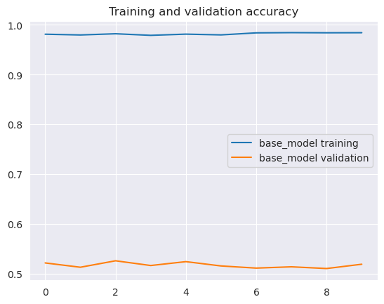

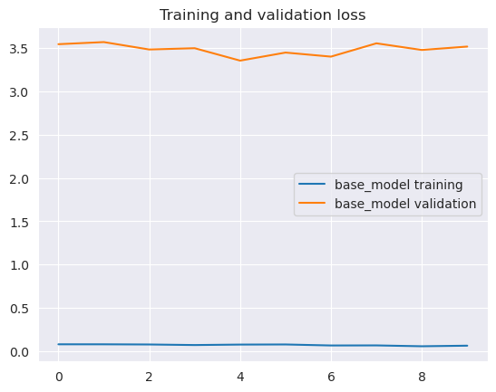

```python
def plot_comparative_history(histories, metric='accuracy'):
    for label, hist in histories.items():
        plt.plot(hist.history[metric], label=label + ' training')
        plt.plot(hist.history['val_' + metric], label=label + ' validation')
    plt.title(f'Training and validation {metric}')
    plt.legend()
    plt.show()

plot_comparative_history({'base_model': history}, metric='accuracy')
plot_comparative_history({'base_model': history}, metric='loss')
```

#### Identify the most challenging poses

```python
challenging_poses = pd.Series(y_true[y_pred != y_true]).value_counts().head(10)
challenging_poses.index = challenging_poses.index.map(lambda x: class_names[x])
print('Most challenging poses:')
print(challenging_poses)
```

```
Most challenging poses:
Half Lord of the Fishes Pose     10
Camel Pose                       10
Cow Pose                         10
Four-Limbed Staff Pose           10
Eagle Pose                        9
Crow Pose                         9
Side Plank Pose                   9
Supported Shoulder Stand Pose     8
Upward Bow Pose (Wheel Pose)      8
Child's Pose                      8
dtype: int64
```

### Track experiments and model convergence

```python
base_model_performance = {
    "accuracy": test_accuracy,
    "f1_score": f1_score(y_true, y_pred, average='weighted'),
    "confusion_matrix": cm
}
```

```python
history_df = pd.DataFrame(history.history)
history_df['epoch'] = history_df.index + 1
print(history_df)
```

```
   accuracy      loss  val_accuracy  val_loss  learning_rate  epoch
0  0.981308  0.077999      0.522040  3.545893          0.001      1
1  0.979801  0.077886      0.513397  3.570304          0.001      2
2  0.982213  0.075898      0.526361  3.484586          0.001      3
3  0.979047  0.069388      0.516854  3.499546          0.001      4
4  0.981459  0.074841      0.524633  3.356039          0.001      5
5  0.979952  0.076125      0.515990  3.449042          0.001      6
6  0.984022  0.064328      0.511668  3.402213          0.001      7
7  0.984474  0.065222      0.514261  3.555947          0.001      8
8  0.984172  0.055269      0.510804  3.479227          0.001      9
9  0.984323  0.062070      0.519447  3.518417          0.001     10
```

### Analyze TensorBoard

```python
% tensorboard --logdir=.
```

## C)

### Update model architecture

```python
model = Sequential([
    Input(shape=(224, 224, 3)),

    Conv2D(32, (3, 3), activation='relu', kernel_regularizer=l1_l2(l1=1e-5, l2=1e-4)),
    BatchNormalization(),
    MaxPooling2D((2, 2)),

    Conv2D(64, (3, 3), activation='relu', kernel_regularizer=l1_l2(l1=1e-5, l2=1e-4)),
    BatchNormalization(),
    MaxPooling2D((2, 2)),

    Conv2D(128, (3, 3), activation='relu', kernel_regularizer=l1_l2(l1=1e-5, l2=1e-4)),
    BatchNormalization(),
    MaxPooling2D((2, 2)),

    Conv2D(256, (3, 3), activation='relu', kernel_regularizer=l1_l2(l1=1e-5, l2=1e-4)),
    BatchNormalization(),
    MaxPooling2D((2, 2)),

    Conv2D(512, (3, 3), activation='relu', kernel_regularizer=l1_l2(l1=1e-5, l2=1e-4)),
    BatchNormalization(),
    MaxPooling2D((2, 2)),

    Flatten(),

    Dense(1024, activation='relu', kernel_regularizer=l1_l2(l1=1e-5, l2=1e-4)),
    BatchNormalization(),
    Dropout(0.5),

    Dense(1024, activation='relu', kernel_regularizer=l1_l2(l1=1e-5, l2=1e-4)),
    BatchNormalization(),
    Dropout(0.5),

    Dense(1024, activation='relu', kernel_regularizer=l1_l2(l1=1e-5, l2=1e-4)),
    BatchNormalization(),
    Dropout(0.5),

    Dense(num_classes, activation='softmax')
])
```

```python
optimizer = Adam(learning_rate=0.001, beta_1=0.85, beta_2=0.99)

model.compile(
    optimizer=optimizer,
    loss='sparse_categorical_crossentropy',
    metrics=['accuracy']
)

early_stopping = EarlyStopping(monitor='val_loss', patience=10, restore_best_weights=True)
reduce_lr = ReduceLROnPlateau(monitor='val_loss', factor=0.2, patience=5, min_lr=0.0001)
tensorboard = TensorBoard(log_dir=os.path.join("logs", "fit", "yoga_pose_model"))

callbacks = [early_stopping, reduce_lr, tensorboard]

history = model.fit(
    train_dataset,
    epochs=50,
    validation_data=val_dataset,
    callbacks=callbacks
)
```

```
I0000 00:00:1720671696.359625  154203 asm_compiler.cc:369] ptxas warning : Registers are spilled to local memory in function 'triton_gemm_dot_4580', 540 bytes spill stores, 540 bytes spill loads

I0000 00:00:1720671696.376609  154213 asm_compiler.cc:369] ptxas warning : Registers are spilled to local memory in function 'triton_gemm_dot_4580', 544 bytes spill stores, 544 bytes spill loads
```

```
207/208 ━━━━━━━━━━━━━━━━━━━━ 0s 25ms/step - accuracy: 0.0169 - loss: 8.6931
```

```
I0000 00:00:1720671707.451968  154392 asm_compiler.cc:369] ptxas warning : Registers are spilled to local memory in function 'triton_gemm_dot_4580', 516 bytes spill stores, 516 bytes spill loads

I0000 00:00:1720671707.465286  154396 asm_compiler.cc:369] ptxas warning : Registers are spilled to local memory in function 'triton_gemm_dot_4580', 516 bytes spill stores, 516 bytes spill loads
```

```
208/208 ━━━━━━━━━━━━━━━━━━━━ 21s 58ms/step - accuracy: 0.0170 - loss: 8.6912 - val_accuracy: 0.0320 - val_loss: 7.6542 - learning_rate: 0.0010
208/208 ━━━━━━━━━━━━━━━━━━━━ 5s 25ms/step - accuracy: 0.0461 - loss: 7.9980 - val_accuracy: 0.0968 - val_loss: 7.4493 - learning_rate: 0.0010
208/208 ━━━━━━━━━━━━━━━━━━━━ 6s 27ms/step - accuracy: 0.1145 - loss: 7.2560 - val_accuracy: 0.1755 - val_loss: 7.1831 - learning_rate: 0.0010
208/208 ━━━━━━━━━━━━━━━━━━━━ 5s 26ms/step - accuracy: 0.1830 - loss: 6.7050 - val_accuracy: 0.2515 - val_loss: 6.4010 - learning_rate: 0.0010
208/208 ━━━━━━━━━━━━━━━━━━━━ 5s 25ms/step - accuracy: 0.2361 - loss: 6.3894 - val_accuracy: 0.2826 - val_loss: 6.3333 - learning_rate: 0.0010
208/208 ━━━━━━━━━━━━━━━━━━━━ 5s 25ms/step - accuracy: 0.2878 - loss: 6.3165 - val_accuracy: 0.3440 - val_loss: 6.1326 - learning_rate: 0.0010
208/208 ━━━━━━━━━━━━━━━━━━━━ 5s 25ms/step - accuracy: 0.3510 - loss: 6.0464 - val_accuracy: 0.3924 - val_loss: 6.0291 - learning_rate: 0.0010
208/208 ━━━━━━━━━━━━━━━━━━━━ 6s 29ms/step - accuracy: 0.4182 - loss: 5.8791 - val_accuracy: 0.2273 - val_loss: 7.3736 - learning_rate: 0.0010
208/208 ━━━━━━━━━━━━━━━━━━━━ 6s 28ms/step - accuracy: 0.4767 - loss: 5.7770 - val_accuracy: 0.3933 - val_loss: 6.3655 - learning_rate: 0.0010
208/208 ━━━━━━━━━━━━━━━━━━━━ 5s 26ms/step - accuracy: 0.5200 - loss: 5.6939 - val_accuracy: 0.4408 - val_loss: 6.3660 - learning_rate: 0.0010
208/208 ━━━━━━━━━━━━━━━━━━━━ 5s 25ms/step - accuracy: 0.5840 - loss: 5.6473 - val_accuracy: 0.4702 - val_loss: 6.4075 - learning_rate: 0.0010
208/208 ━━━━━━━━━━━━━━━━━━━━ 6s 27ms/step - accuracy: 0.6097 - loss: 5.7098 - val_accuracy: 0.2930 - val_loss: 7.4654 - learning_rate: 0.0010
208/208 ━━━━━━━━━━━━━━━━━━━━ 8s 37ms/step - accuracy: 0.7415 - loss: 5.2023 - val_accuracy: 0.5627 - val_loss: 5.9892 - learning_rate: 2.0000e-04
208/208 ━━━━━━━━━━━━━━━━━━━━ 8s 39ms/step - accuracy: 0.8306 - loss: 4.6898 - val_accuracy: 0.5791 - val_loss: 5.8034 - learning_rate: 2.0000e-04
208/208 ━━━━━━━━━━━━━━━━━━━━ 7s 32ms/step - accuracy: 0.8748 - loss: 4.3483 - val_accuracy: 0.5696 - val_loss: 5.6429 - learning_rate: 2.0000e-04
208/208 ━━━━━━━━━━━━━━━━━━━━ 5s 25ms/step - accuracy: 0.9072 - loss: 4.0565 - val_accuracy: 0.5523 - val_loss: 5.5252 - learning_rate: 2.0000e-04
208/208 ━━━━━━━━━━━━━━━━━━━━ 5s 25ms/step - accuracy: 0.9267 - loss: 3.8068 - val_accuracy: 0.5549 - val_loss: 5.3670 - learning_rate: 2.0000e-04
208/208 ━━━━━━━━━━━━━━━━━━━━ 5s 25ms/step - accuracy: 0.9444 - loss: 3.5836 - val_accuracy: 0.5687 - val_loss: 5.2455 - learning_rate: 2.0000e-04
208/208 ━━━━━━━━━━━━━━━━━━━━ 5s 25ms/step - accuracy: 0.9512 - loss: 3.4050 - val_accuracy: 0.5618 - val_loss: 5.1289 - learning_rate: 2.0000e-04
208/208 ━━━━━━━━━━━━━━━━━━━━ 5s 25ms/step - accuracy: 0.9506 - loss: 3.2503 - val_accuracy: 0.5791 - val_loss: 5.0059 - learning_rate: 2.0000e-04
208/208 ━━━━━━━━━━━━━━━━━━━━ 5s 26ms/step - accuracy: 0.9584 - loss: 3.0924 - val_accuracy: 0.5627 - val_loss: 4.9702 - learning_rate: 2.0000e-04
208/208 ━━━━━━━━━━━━━━━━━━━━ 5s 25ms/step - accuracy: 0.9605 - loss: 2.9729 - val_accuracy: 0.5601 - val_loss: 4.9209 - learning_rate: 2.0000e-04
208/208 ━━━━━━━━━━━━━━━━━━━━ 5s 25ms/step - accuracy: 0.9647 - loss: 2.8430 - val_accuracy: 0.5480 - val_loss: 4.8424 - learning_rate: 2.0000e-04
208/208 ━━━━━━━━━━━━━━━━━━━━ 5s 25ms/step - accuracy: 0.9693 - loss: 2.7265 - val_accuracy: 0.5557 - val_loss: 4.7201 - learning_rate: 2.0000e-04
208/208 ━━━━━━━━━━━━━━━━━━━━ 6s 27ms/step - accuracy: 0.9632 - loss: 2.6559 - val_accuracy: 0.5566 - val_loss: 4.6896 - learning_rate: 2.0000e-04
208/208 ━━━━━━━━━━━━━━━━━━━━ 6s 28ms/step - accuracy: 0.9703 - loss: 2.5573 - val_accuracy: 0.5583 - val_loss: 4.6362 - learning_rate: 2.0000e-04
208/208 ━━━━━━━━━━━━━━━━━━━━ 6s 28ms/step - accuracy: 0.9701 - loss: 2.4779 - val_accuracy: 0.5601 - val_loss: 4.6437 - learning_rate: 2.0000e-04
208/208 ━━━━━━━━━━━━━━━━━━━━ 6s 28ms/step - accuracy: 0.9700 - loss: 2.4254 - val_accuracy: 0.5445 - val_loss: 4.5326 - learning_rate: 2.0000e-04
208/208 ━━━━━━━━━━━━━━━━━━━━ 6s 28ms/step - accuracy: 0.9680 - loss: 2.3636 - val_accuracy: 0.5687 - val_loss: 4.4623 - learning_rate: 2.0000e-04
208/208 ━━━━━━━━━━━━━━━━━━━━ 6s 28ms/step - accuracy: 0.9714 - loss: 2.2994 - val_accuracy: 0.5713 - val_loss: 4.4850 - learning_rate: 2.0000e-04
208/208 ━━━━━━━━━━━━━━━━━━━━ 6s 28ms/step - accuracy: 0.9696 - loss: 2.2540 - val_accuracy: 0.5557 - val_loss: 4.4498 - learning_rate: 2.0000e-04
208/208 ━━━━━━━━━━━━━━━━━━━━ 6s 28ms/step - accuracy: 0.9695 - loss: 2.2125 - val_accuracy: 0.5411 - val_loss: 4.3936 - learning_rate: 2.0000e-04
208/208 ━━━━━━━━━━━━━━━━━━━━ 6s 28ms/step - accuracy: 0.9669 - loss: 2.1842 - val_accuracy: 0.5730 - val_loss: 4.3827 - learning_rate: 2.0000e-04
```

[output cut: 17 more lines]